# Prediction Assignment Writeup

Luciano Guerra

April 1, 2019

# Prediction Assignment Writeup - Project Assignment

## Background

Using devices such as Jawbone Up, Nike FuelBand, and Fitbit it is now possible to collect a large amount of data about personal activity relatively inexpensively. These type of devices are part of the quantified self movement - a group of enthusiasts who take measurements about themselves regularly to improve their health, to find patterns in their behavior, or because they are tech geeks. One thing that people regularly do is quantify how much of a particular activity they do, but they rarely quantify how well they do it. In this project, your goal will be to use data from accelerometers on the belt, forearm, arm, and dumbell of 6 participants. They were asked to perform barbell lifts correctly and incorrectly in 5 different ways. More information is available from the website here: http://web.archive.org/web/20161224072740/http:/groupware.les.inf.puc-rio.br/har (see the section on the Weight Lifting Exercise Dataset).

## Data

The training data for this project are available here: https://d396qusza40orc.cloudfront.net/predmachlearn/pml-training.csv

The test data are available here: https://d396qusza40orc.cloudfront.net/predmachlearn/pml-testing.csv

The data for this project come from this source: http://web.archive.org/web/20161224072740/http:/groupware.les.inf.puc-rio.br/har. If you use the document you create for this class for any purpose please cite them as they have been very generous in allowing their data to be used for this kind of assignment.

## What you should submit

The goal of your project is to predict the manner in which they did the exercise. This is the “classe” variable in the training set. You may use any of the other variables to predict with. You should create a report describing how you built your model, how you used cross validation, what you think the expected out of sample error is, and why you made the choices you did. You will also use your prediction model to predict 20 different test cases.

### Peer Review Portion

Your submission for the Peer Review portion should consist of a link to a Github repo with your R markdown and compiled HTML file describing your analysis. Please constrain the text of the writeup to < 2000 words and the number of figures to be less than 5. It will make it easier for the graders if you submit a repo with a gh-pages branch so the HTML page can be viewed online (and you always want to make it easy on gradees.

### Course Project Prediction Quiz Portion

Apply your machine learning algorithm to the 20 test cases available in the test data above and submit your predictions in appropriate format to the Course Project Prediction Quiz for automated grading.

## Data Processing

### Libraries needed and download data. Clean the data as well.

```r
# library
library(caret)
```

```r
library(ggplot2)
library(rattle)
library(rpart.plot)
library(corrplot)
library(randomForest)
library(RColorBrewer)
setwd("E:/Luciano/R_WorkingDir/Project01")
rm(list = ls())
```

```r
# donwloada data
urlTrain <- "https://d396qusza40orc.cloudfront.net/predmachlearn/pml-training.csv"
urlTest <- "https://d396qusza40orc.cloudfront.net/predmachlearn/pml-testing.csv"
csvTrain <- "pml-training.csv"
csvTest <-  "pml-testing.csv"

if (file.exists(csvTrain)) {
        training <- read.csv(csvTrain, na.strings=c("NA","#DIV/0!",""))
} else {
        download.file(urlTrain,csvTrain)
        training <- read.csv(csvTrain, na.strings=c("NA","#DIV/0!",""))
}


if (file.exists(csvTest)) {
        testing <- read.csv(csvTest, na.strings=c("NA","#DIV/0!",""))
} else {
        download.file(urlTest,csvTest)
        testing <- read.csv(csvTest, na.strings=c("NA","#DIV/0!",""))
}
dim(training)
```

```
## [1] 19622   160
```

```r
dim(testing)
```

```
## [1]  20 160
```

```r
sum(is.na(training))
```

```
## [1] 1925102
```

```r
rm(urlTrain)
rm(urlTest)
```

Data sets are as follow: * Training data + Obesrvations: 19622 + Variables: 160 * Testing data + Obesrvations: 20 + Variables: 160

### Cleaning data

#### Remove **Near to Zero varianze (NZV)** variables

```r
NZV <- nearZeroVar(training, saveMetrics = TRUE)
head(NZV, 20)
```

```
##                      freqRatio percentUnique zeroVar   nzv
## X                     1.000000  100.00000000   FALSE FALSE
## user_name             1.100679    0.03057792   FALSE FALSE
## raw_timestamp_part_1  1.000000    4.26562022   FALSE FALSE
## raw_timestamp_part_2  1.000000   85.53154622   FALSE FALSE
## cvtd_timestamp        1.000668    0.10192641   FALSE FALSE
## new_window           47.330049    0.01019264   FALSE  TRUE
## num_window            1.000000    4.37264295   FALSE FALSE
## roll_belt             1.101904    6.77810621   FALSE FALSE
## pitch_belt            1.036082    9.37722964   FALSE FALSE
## yaw_belt              1.058480    9.97349913   FALSE FALSE
## total_accel_belt      1.063160    0.14779329   FALSE FALSE
## kurtosis_roll_belt    2.000000    2.01304658   FALSE FALSE
## kurtosis_picth_belt   1.333333    1.60534094   FALSE FALSE
## kurtosis_yaw_belt     0.000000    0.00000000    TRUE  TRUE
## skewness_roll_belt    2.000000    2.00285394   FALSE FALSE
## skewness_roll_belt.1  1.333333    1.71236367   FALSE FALSE
## skewness_yaw_belt     0.000000    0.00000000    TRUE  TRUE
## max_roll_belt         1.000000    0.99378249   FALSE FALSE
## max_picth_belt        1.538462    0.11211905   FALSE FALSE
## max_yaw_belt          1.034483    0.33635715   FALSE FALSE
```

```r
trainingNZV <- training[, !NZV$nzv]
testingNZV <- testing[, !NZV$nzv]
dim(trainingNZV)
```

```
## [1] 19622   124
```

```r
dim(testingNZV)
```

```
## [1]  20 124
```

```r
rm(training)
rm(testing)
rm(NZV)
```

#### Remove some other columns with no information

```r
noInfoCol <- grepl("^X|timestamp|user_name", names(trainingNZV))
trainingNZVCol <- trainingNZV[, !noInfoCol]
testingNZVCol <- testingNZV[, !noInfoCol]
rm(noInfoCol)
rm(trainingNZV)
rm(testingNZV)
dim(trainingNZVCol)
```

```
## [1] 19622   119
```

```r
dim(testingNZVCol)
```

```
## [1]  20 119
```

#### Remove columns with `NA's`.

```r
NACols <- (colSums(is.na(trainingNZVCol)) == 0)
trainingNew <- trainingNZVCol[, NACols]
testingNew <- testingNZVCol[, NACols]
rm(trainingNZVCol)
rm(testingNZVCol)
rm(NACols)
```

Data sets updated are as follow: * Training data + Obesrvations: 19622 + Variables: 54 * Testing data + Obesrvations: 20 + Variables: 54

### Partitioning the training set into two

Partioning Training data set into two data sets, 60% for newTraining, 40% for newTesting

```
## [1] 11776    54
```

```
## [1] 7846   54
```

The Dataset now consists of 54 variables with the observations divided as following:  
1. Training Data: 11776 observations.  
2. Validation Data: 7846 observations.  
3. Testing Data: 20 observations.

## Data Modeling - ML algorithms for prediction

### Decision Tree

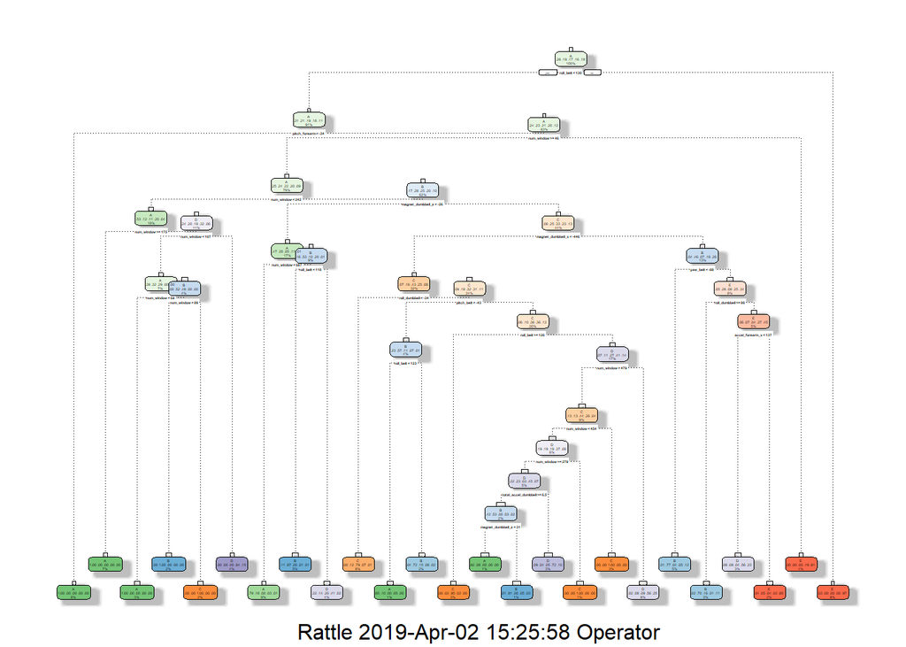

```r
modFitDT <- rpart(classe ~., data = newTraining, method = "class")
fancyRpartPlot(modFitDT)
```

#### Predicting

```
## Confusion Matrix and Statistics
##
##           Reference
## Prediction    A    B    C    D    E
##          A 1971   56    0  155   50
##          B  113 1206   81  113    5
##          C    3   79 1135  146    5
##          D   24   65   50 1078   69
##          E    0   94    2  335 1011
##
## Overall Statistics
##
##                Accuracy : 0.8158
##                  95% CI : (0.8071, 0.8244)
##     No Information Rate : 0.2691
##     P-Value [Acc > NIR] : < 2.2e-16
##
##                   Kappa : 0.7679
##
##  Mcnemar's Test P-Value : < 2.2e-16
##
## Statistics by Class:
##
##                      Class: A Class: B Class: C Class: D Class: E
## Sensitivity            0.9337   0.8040   0.8951   0.5900   0.8868
## Specificity            0.9545   0.9508   0.9646   0.9654   0.9357
## Pos Pred Value         0.8831   0.7945   0.8297   0.8383   0.7011
## Neg Pred Value         0.9751   0.9535   0.9795   0.8858   0.9799
## Prevalence             0.2691   0.1912   0.1616   0.2329   0.1453
## Detection Rate         0.2512   0.1537   0.1447   0.1374   0.1289
## Detection Prevalence   0.2845   0.1935   0.1744   0.1639   0.1838
## Balanced Accuracy      0.9441   0.8774   0.9298   0.7777   0.9113
```

### Random Forest

We fit a predictive model for activity recognition using **Random Forest** algorithm because it automatically selects important variables and is robust to correlated covariates & outliers in general.  
We will use **5-fold cross validation** when applying the algorithm.

```r
modFitRF <- train(classe ~ ., data = newTraining, method = "rf", trControl = trainControl(method = "cv", 5), ntree = 250)
modFitRF
```

```
## Random Forest
##
## 11776 samples
##    53 predictor
##     5 classes: 'A', 'B', 'C', 'D', 'E'
##
## No pre-processing
## Resampling: Cross-Validated (5 fold)
## Summary of sample sizes: 9422, 9420, 9420, 9421, 9421
## Resampling results across tuning parameters:
##
##   mtry  Accuracy   Kappa
##    2    0.9921025  0.9900092
##   27    0.9954146  0.9941996
##   53    0.9942258  0.9926957
##
## Accuracy was used to select the optimal model using the largest value.
## The final value used for the model was mtry = 27.
```

#### Predicting

```r
predictRF <- predict(modFitRF, newTesting)
confusionMatrix(newTesting$classe, predictRF)
```

```
## Confusion Matrix and Statistics
##
##           Reference
## Prediction    A    B    C    D    E
##          A 2230    0    0    0    2
##          B    1 1515    2    0    0
##          C    0    3 1365    0    0
##          D    0    0    2 1284    0
##          E    0    0    0    1 1441
##
## Overall Statistics
##
##                Accuracy : 0.9986
##                  95% CI : (0.9975, 0.9993)
##     No Information Rate : 0.2843
##     P-Value [Acc > NIR] : < 2.2e-16
##
##                   Kappa : 0.9982
##
##  Mcnemar's Test P-Value : NA
##
## Statistics by Class:
##
##                      Class: A Class: B Class: C Class: D Class: E
## Sensitivity            0.9996   0.9980   0.9971   0.9992   0.9986
## Specificity            0.9996   0.9995   0.9995   0.9997   0.9998
## Pos Pred Value         0.9991   0.9980   0.9978   0.9984   0.9993
## Neg Pred Value         0.9998   0.9995   0.9994   0.9998   0.9997
## Prevalence             0.2843   0.1935   0.1745   0.1638   0.1839
## Detection Rate         0.2842   0.1931   0.1740   0.1637   0.1837
## Detection Prevalence   0.2845   0.1935   0.1744   0.1639   0.1838
## Balanced Accuracy      0.9996   0.9988   0.9983   0.9995   0.9992
```

```r
accuracy <- postResample(predictRF, newTesting$classe)
ose <- 1 - as.numeric(confusionMatrix(newTesting$classe, predictRF)$overall[1])
rm(predictRF)
```

The Estimated Accuracy of the Random Forest Model is 99.8598012% and the Estimated Out-of-Sample Error is 0.1401988%.  
Random Forests yielded better Results, as expected!

## Predicting The Manner of Exercise for Test Data Set

Now, we apply the **Random Forest** model to the original testing data set downloaded from the data source. We remove the problem_id column first.

```r
rm(accuracy)
rm(ose)
predict(modFitRF, testingNew[, -length(names(testingNew))])
```

```
##  [1] B A B A A E D B A A B C B A E E A B B B
## Levels: A B C D E
```

## Files for the Assignment - Submission to Coursera

```r
pml_write_files = function(x){
  n = length(x)
  for(i in 1:n){
    filename = paste0("./AssignementFiles/problem_id_",i,".txt")
    write.table(x[i], file = filename, quote = FALSE, row.names = FALSE, col.names = FALSE)
  }
}

pml_write_files(predict(modFitRF, testingNew[, -length(names(testingNew))]))
rm(modFitRF)
rm(trainingNew)
rm(testingNew)
rm(newTesting)
rm(pml_write_files)
```